# FML-FINAL PROJECT

##### Performing Descreptive statistics to better understand the dataset.

```r
# DESCRIPTIVE AND BASIC STATISTICS:
# 1.Summary Statistics:
summary(final_dataset) # Summary gives us an idea about the mean, median, maximum and minimum value of all the variables belonging to the dataset.
```

```
##       Age         Workclass          Final.Weight      Education
##  Min.   :17.00   Length:30162       Min.   :  13769   Length:30162
##  1st Qu.:28.00   Class :character   1st Qu.: 117627   Class :character
##  Median :37.00   Mode  :character   Median : 178425   Mode  :character
##  Mean   :38.44                      Mean   : 189794
##  3rd Qu.:47.00                      3rd Qu.: 237628
##  Max.   :90.00                      Max.   :1484705
##   EducationNum   Marital.Status      Occupation        Relationship
##  Min.   : 1.00   Length:30162       Length:30162       Length:30162
##  1st Qu.: 9.00   Class :character   Class :character   Class :character
##  Median :10.00   Mode  :character   Mode  :character   Mode  :character
##  Mean   :10.12
##  3rd Qu.:13.00
##  Max.   :16.00
##      Race              Gender           Capital.Gain    capital.loss
##  Length:30162       Length:30162       Min.   :    0   Min.   :   0.00
##  Class :character   Class :character   1st Qu.:    0   1st Qu.:   0.00
##  Mode  :character   Mode  :character   Median :    0   Median :   0.00
##                                        Mean   : 1092   Mean   :  88.37
##                                        3rd Qu.:    0   3rd Qu.:   0.00
##                                        Max.   :99999   Max.   :4356.00
##  Hours.per.Week  Native.Country        Income
##  Min.   : 1.00   Length:30162       Length:30162
##  1st Qu.:40.00   Class :character   Class :character
##  Median :40.00   Mode  :character   Mode  :character
##  Mean   :40.93
##  3rd Qu.:45.00
##  Max.   :99.00
```

- Below is the scatter plot for Target variable - Income and Input variable - Age. It shows that age alone cannot be a good input variable to determine the income accurately, but when combined with other input variables, it can do a much better job.

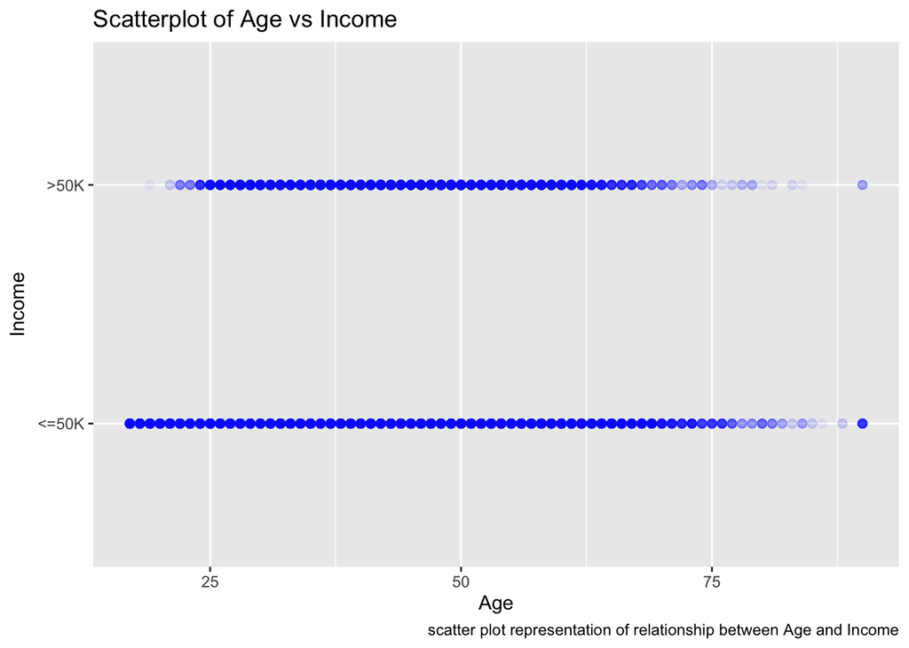

```r
# 2. Scatter plot:
library(ggplot2)
scatter_plot <- ggplot(final_dataset,aes(x=final_dataset$Age,y=final_dataset$Income))+ geom_point(color="blue",size=2,alpha=0.05)+labs(title = "Scatterplot of Age vs Income",x="Age",y="Income",caption = "scatter plot representation of relationship between Age and Income")
scatter_plot
```

- Below is the barplot for the Target Variable - Income. It shows the distribution between the levels of target variable, and it is obvious that people who earn less than or equal to 50k are higher than people who earn more than 50k.

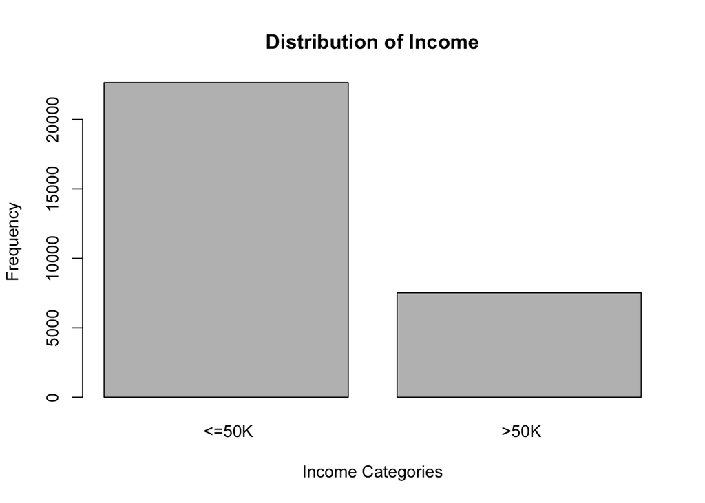

```r
# 3. BARPLOT:
barplot <- barplot(table(final_dataset$Income),
        main = "Distribution of Income",
        xlab = "Income Categories",
        ylab = "Frequency")
```

##### In this step, we aim to convert all categorical variable columns into dummy varibales using ‘One-Hot-Encoding’

```r
# CONVERTING CATEGORICAL VARIABLES TO NUMERIC BY ONE-HOT ENCODING:
library(caret)
dummy_workclass <- dummyVars(~Workclass, data=final_dataset)
dummy_education <- dummyVars(~Education, data=final_dataset)
dummy_marital <- dummyVars(~Marital.Status, data=final_dataset)
dummy_occupation <- dummyVars(~Occupation, data=final_dataset)
dummy_relationship <- dummyVars(~Relationship, data=final_dataset)
dummy_race <- dummyVars(~Race, data=final_dataset)
dummy_gender <- dummyVars(~Gender, data=final_dataset)
dummy_native <- dummyVars(~Native.Country, data=final_dataset)
dummy_income <- dummyVars(~Income, data=final_dataset)
encoded_final_dataset <- cbind(final_dataset,
                         predict(dummy_workclass, final_dataset),
                         predict(dummy_education, final_dataset),
                         predict(dummy_marital, final_dataset),
                         predict(dummy_occupation, final_dataset),
                         predict(dummy_relationship, final_dataset),
                         predict(dummy_race, final_dataset),
                         predict(dummy_gender, final_dataset),
                         predict(dummy_native, final_dataset),
                         predict(dummy_income, final_dataset))
encoded_final_dataset <- encoded_final_dataset[, -c(2,4,6,7,8,9,10,14,15)]
```

##### Normalizing the entire dataset using preProcess function to bring all the variables to a common scale, for unbiased analysis.

```r
# NORMALIZING THE DATA:
summary(encoded_final_dataset)
```

```
##       Age         Final.Weight      EducationNum    Capital.Gain
##  Min.   :17.00   Min.   :  13769   Min.   : 1.00   Min.   :    0
##  1st Qu.:28.00   1st Qu.: 117627   1st Qu.: 9.00   1st Qu.:    0
##  Median :37.00   Median : 178425   Median :10.00   Median :    0
##  Mean   :38.44   Mean   : 189794   Mean   :10.12   Mean   : 1092
##  3rd Qu.:47.00   3rd Qu.: 237628   3rd Qu.:13.00   3rd Qu.:    0
##  Max.   :90.00   Max.   :1484705   Max.   :16.00   Max.   :99999
##   capital.loss     Hours.per.Week  Workclass Federal-gov Workclass Local-gov
##  Min.   :   0.00   Min.   : 1.00   Min.   :0.00000       Min.   :0.00000
##  1st Qu.:   0.00   1st Qu.:40.00   1st Qu.:0.00000       1st Qu.:0.00000
##  Median :   0.00   Median :40.00   Median :0.00000       Median :0.00000
##  Mean   :  88.37   Mean   :40.93   Mean   :0.03126       Mean   :0.06853
##  3rd Qu.:   0.00   3rd Qu.:45.00   3rd Qu.:0.00000       3rd Qu.:0.00000
##  Max.   :4356.00   Max.   :99.00   Max.   :1.00000       Max.   :1.00000
##  Workclass Private Workclass Self-emp-inc Workclass Self-emp-not-inc
##  Min.   :0.0000    Min.   :0.00000        Min.   :0.00000
##  1st Qu.:0.0000    1st Qu.:0.00000        1st Qu.:0.00000
##  Median :1.0000    Median :0.00000        Median :0.00000
##  Mean   :0.7389    Mean   :0.03561        Mean   :0.08285
##  3rd Qu.:1.0000    3rd Qu.:0.00000        3rd Qu.:0.00000
##  Max.   :1.0000    Max.   :1.00000        Max.   :1.00000
##  Workclass State-gov Workclass Without-pay Education 10th    Education 11th
##  Min.   :0.0000      Min.   :0.0000000     Min.   :0.00000   Min.   :0.00000
##  1st Qu.:0.0000      1st Qu.:0.0000000     1st Qu.:0.00000   1st Qu.:0.00000
##  Median :0.0000      Median :0.0000000     Median :0.00000   Median :0.00000
##  Mean   :0.0424      Mean   :0.0004642     Mean   :0.02719   Mean   :0.03475
##  3rd Qu.:0.0000      3rd Qu.:0.0000000     3rd Qu.:0.00000   3rd Qu.:0.00000
##  Max.   :1.0000      Max.   :1.0000000     Max.   :1.00000   Max.   :1.00000
##  Education 12th   Education 1st-4th  Education 5th-6th  Education 7th-8th
##  Min.   :0.0000   Min.   :0.000000   Min.   :0.000000   Min.   :0.00000
##  1st Qu.:0.0000   1st Qu.:0.000000   1st Qu.:0.000000   1st Qu.:0.00000
##  Median :0.0000   Median :0.000000   Median :0.000000   Median :0.00000
##  Mean   :0.0125   Mean   :0.005006   Mean   :0.009548   Mean   :0.01847
##  3rd Qu.:0.0000   3rd Qu.:0.000000   3rd Qu.:0.000000   3rd Qu.:0.00000
##  Max.   :1.0000   Max.   :1.000000   Max.   :1.000000   Max.   :1.00000
##  Education 9th     Education Assoc-acdm Education Assoc-voc Education Bachelors
##  Min.   :0.00000   Min.   :0.00000      Min.   :0.00000     Min.   :0.0000
##  1st Qu.:0.00000   1st Qu.:0.00000      1st Qu.:0.00000     1st Qu.:0.0000
##  Median :0.00000   Median :0.00000      Median :0.00000     Median :0.0000
##  Mean   :0.01509   Mean   :0.03342      Mean   :0.04333     Mean   :0.1672
```

[output cut: 197 more lines]

```
##  Max.   :1.000000      Max.   :1.0000000       Max.   :1.0000000
##  Native.Country United-States Native.Country Vietnam Native.Country Yugoslavia
##  Min.   :0.0000               Min.   :0.000000       Min.   :0.0000000
##  1st Qu.:1.0000               1st Qu.:0.000000       1st Qu.:0.0000000
##  Median :1.0000               Median :0.000000       Median :0.0000000
##  Mean   :0.9119               Mean   :0.002122       Mean   :0.0005305
##  3rd Qu.:1.0000               3rd Qu.:0.000000       3rd Qu.:0.0000000
##  Max.   :1.0000               Max.   :1.000000       Max.   :1.0000000
##   Income <=50K     Income >50K
##  Min.   :0.0000   Min.   :0.0000
##  1st Qu.:1.0000   1st Qu.:0.0000
##  Median :1.0000   Median :0.0000
##  Mean   :0.7511   Mean   :0.2489
##  3rd Qu.:1.0000   3rd Qu.:0.0000
##  Max.   :1.0000   Max.   :1.0000
```

```r
encoded_final_dataset_norm <- preProcess(encoded_final_dataset,method = c('range'))
normalized_dataset <- predict(encoded_final_dataset_norm,encoded_final_dataset)
summary(normalized_dataset)
```

```
##       Age          Final.Weight      EducationNum     Capital.Gain
##  Min.   :0.0000   Min.   :0.00000   Min.   :0.0000   Min.   :0.00000
##  1st Qu.:0.1507   1st Qu.:0.07061   1st Qu.:0.5333   1st Qu.:0.00000
##  Median :0.2740   Median :0.11194   Median :0.6000   Median :0.00000
##  Mean   :0.2937   Mean   :0.11967   Mean   :0.6081   Mean   :0.01092
##  3rd Qu.:0.4110   3rd Qu.:0.15219   3rd Qu.:0.8000   3rd Qu.:0.00000
##  Max.   :1.0000   Max.   :1.00000   Max.   :1.0000   Max.   :1.00000
##   capital.loss     Hours.per.Week   Workclass Federal-gov Workclass Local-gov
##  Min.   :0.00000   Min.   :0.0000   Min.   :0.00000       Min.   :0.00000
##  1st Qu.:0.00000   1st Qu.:0.3980   1st Qu.:0.00000       1st Qu.:0.00000
##  Median :0.00000   Median :0.3980   Median :0.00000       Median :0.00000
##  Mean   :0.02029   Mean   :0.4075   Mean   :0.03126       Mean   :0.06853
##  3rd Qu.:0.00000   3rd Qu.:0.4490   3rd Qu.:0.00000       3rd Qu.:0.00000
##  Max.   :1.00000   Max.   :1.0000   Max.   :1.00000       Max.   :1.00000
##  Workclass Private Workclass Self-emp-inc Workclass Self-emp-not-inc
##  Min.   :0.0000    Min.   :0.00000        Min.   :0.00000
##  1st Qu.:0.0000    1st Qu.:0.00000        1st Qu.:0.00000
##  Median :1.0000    Median :0.00000        Median :0.00000
##  Mean   :0.7389    Mean   :0.03561        Mean   :0.08285
##  3rd Qu.:1.0000    3rd Qu.:0.00000        3rd Qu.:0.00000
##  Max.   :1.0000    Max.   :1.00000        Max.   :1.00000
##  Workclass State-gov Workclass Without-pay Education 10th    Education 11th
##  Min.   :0.0000      Min.   :0.0000000     Min.   :0.00000   Min.   :0.00000
##  1st Qu.:0.0000      1st Qu.:0.0000000     1st Qu.:0.00000   1st Qu.:0.00000
##  Median :0.0000      Median :0.0000000     Median :0.00000   Median :0.00000
##  Mean   :0.0424      Mean   :0.0004642     Mean   :0.02719   Mean   :0.03475
##  3rd Qu.:0.0000      3rd Qu.:0.0000000     3rd Qu.:0.00000   3rd Qu.:0.00000
##  Max.   :1.0000      Max.   :1.0000000     Max.   :1.00000   Max.   :1.00000
##  Education 12th   Education 1st-4th  Education 5th-6th  Education 7th-8th
##  Min.   :0.0000   Min.   :0.000000   Min.   :0.000000   Min.   :0.00000
##  1st Qu.:0.0000   1st Qu.:0.000000   1st Qu.:0.000000   1st Qu.:0.00000
##  Median :0.0000   Median :0.000000   Median :0.000000   Median :0.00000
##  Mean   :0.0125   Mean   :0.005006   Mean   :0.009548   Mean   :0.01847
##  3rd Qu.:0.0000   3rd Qu.:0.000000   3rd Qu.:0.000000   3rd Qu.:0.00000
##  Max.   :1.0000   Max.   :1.000000   Max.   :1.000000   Max.   :1.00000
##  Education 9th     Education Assoc-acdm Education Assoc-voc Education Bachelors
##  Min.   :0.00000   Min.   :0.00000      Min.   :0.00000     Min.   :0.0000
##  1st Qu.:0.00000   1st Qu.:0.00000      1st Qu.:0.00000     1st Qu.:0.0000
##  Median :0.00000   Median :0.00000      Median :0.00000     Median :0.0000
##  Mean   :0.01509   Mean   :0.03342      Mean   :0.04333     Mean   :0.1672
```

[output cut: 197 more lines]

```
##  Max.   :1.000000      Max.   :1.0000000       Max.   :1.0000000
##  Native.Country United-States Native.Country Vietnam Native.Country Yugoslavia
##  Min.   :0.0000               Min.   :0.000000       Min.   :0.0000000
##  1st Qu.:1.0000               1st Qu.:0.000000       1st Qu.:0.0000000
##  Median :1.0000               Median :0.000000       Median :0.0000000
##  Mean   :0.9119               Mean   :0.002122       Mean   :0.0005305
##  3rd Qu.:1.0000               3rd Qu.:0.000000       3rd Qu.:0.0000000
##  Max.   :1.0000               Max.   :1.000000       Max.   :1.0000000
##   Income <=50K     Income >50K
##  Min.   :0.0000   Min.   :0.0000
##  1st Qu.:1.0000   1st Qu.:0.0000
##  Median :1.0000   Median :0.0000
##  Mean   :0.7511   Mean   :0.2489
##  3rd Qu.:1.0000   3rd Qu.:0.0000
##  Max.   :1.0000   Max.   :1.0000
```

##### Now, we are moving to the variable selection process. The idea is to use Corrplot, Backward Stepwise Regression, and PCA to perform variable selection.

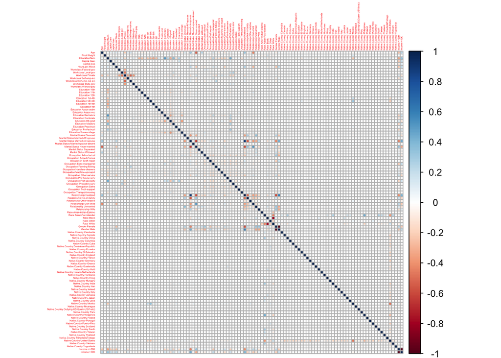

```r
# FEATURE SELECTION (VARIABLE SELECTION)
# 1. Corrplot:
library(corrplot)
cor_matrix <- cor(normalized_dataset[,sapply(normalized_dataset,is.numeric)],use = "complete.obs")
corrplot(cor_matrix, method = "circle",tl.cex=0.2)
```

##### Combining two income columns into one to make it easy to analyze.

```r
# Create a new column 'Combined_Income' based on conditions
normalized_dataset$Combined_Income <- ifelse(normalized_dataset$`Income <=50K` == 1, 0, 1) # In Combined Income column - '0' denotes Income is less than or equal to 50K, and '1' denotes Income being greater than 50K.
# Drop the original income columns:
normalized_dataset <-normalized_dataset[, -c(105,106)]
# Checking names of columns to ensure changes have been made:
colnames(normalized_dataset)
```

```
##   [1] "Age"
##   [2] "Final.Weight"
##   [3] "EducationNum"
##   [4] "Capital.Gain"
##   [5] "capital.loss"
##   [6] "Hours.per.Week"
##   [7] "Workclass Federal-gov"
##   [8] "Workclass Local-gov"
##   [9] "Workclass Private"
##  [10] "Workclass Self-emp-inc"
##  [11] "Workclass Self-emp-not-inc"
##  [12] "Workclass State-gov"
##  [13] "Workclass Without-pay"
##  [14] "Education 10th"
##  [15] "Education 11th"
```

[output cut: 90 more lines]

##### Performed Backward Stepwise regression to identify the most significant input variables.

```r
# 2. Stepwise Regression:
# Load necessary library
library(MASS)

# Fit initial linear regression model with all predictors
initial_model <- lm(Combined_Income ~ ., data = normalized_dataset)

# Perform backward elimination for variable selection
final_model <- step(initial_model, direction = "backward")
```

```
## Start:  AIC=-64326.63
## Combined_Income ~ Age + Final.Weight + EducationNum + Capital.Gain +
##     capital.loss + Hours.per.Week + `Workclass Federal-gov` +
##     `Workclass Local-gov` + `Workclass Private` + `Workclass Self-emp-inc` +
##     `Workclass Self-emp-not-inc` + `Workclass State-gov` + `Workclass Without-pay` +
##     `Education 10th` + `Education 11th` + `Education 12th` +
##     `Education 1st-4th` + `Education 5th-6th` + `Education 7th-8th` +
##     `Education 9th` + `Education Assoc-acdm` + `Education Assoc-voc` +
##     `Education Bachelors` + `Education Doctorate` + `Education HS-grad` +
##     `Education Masters` + `Education Preschool` + `Education Prof-school` +
##     `Education Some-college` + `Marital.Status Divorced` + `Marital.Status Married-AF-spouse` +
##     `Marital.Status Married-civ-spouse` + `Marital.Status Married-spouse-absent` +
##     `Marital.Status Never-married` + `Marital.Status Separated` +
##     `Marital.Status Widowed` + `Occupation Adm-clerical` + `Occupation Armed-Forces` +
##     `Occupation Craft-repair` + `Occupation Exec-managerial` +
##     `Occupation Farming-fishing` + `Occupation Handlers-cleaners` +
##     `Occupation Machine-op-inspct` + `Occupation Other-service` +
##     `Occupation Priv-house-serv` + `Occupation Prof-specialty` +
##     `Occupation Protective-serv` + `Occupation Sales` + `Occupation Tech-support` +
##     `Occupation Transport-moving` + `Relationship Husband` +
##     `Relationship Not-in-family` + `Relationship Other-relative` +
##     `Relationship Own-child` + `Relationship Unmarried` + `Relationship Wife` +
##     `Race Amer-Indian-Eskimo` + `Race Asian-Pac-Islander` + `Race Black` +
##     `Race Other` + `Race White` + `Gender Female` + `Gender Male` +
##     `Native.Country Cambodia` + `Native.Country Canada` + `Native.Country China` +
##     `Native.Country Columbia` + `Native.Country Cuba` + `Native.Country Dominican-Republic` +
##     `Native.Country Ecuador` + `Native.Country El-Salvador` +
##     `Native.Country England` + `Native.Country France` + `Native.Country Germany` +
##     `Native.Country Greece` + `Native.Country Guatemala` + `Native.Country Haiti` +
##     `Native.Country Holand-Netherlands` + `Native.Country Honduras` +
##     `Native.Country Hong` + `Native.Country Hungary` + `Native.Country India` +
##     `Native.Country Iran` + `Native.Country Ireland` + `Native.Country Italy` +
##     `Native.Country Jamaica` + `Native.Country Japan` + `Native.Country Laos` +
##     `Native.Country Mexico` + `Native.Country Nicaragua` + `Native.Country Outlying-US(Guam-USVI-etc)` +
##     `Native.Country Peru` + `Native.Country Philippines` + `Native.Country Poland` +
##     `Native.Country Portugal` + `Native.Country Puerto-Rico` +
##     `Native.Country Scotland` + `Native.Country South` + `Native.Country Taiwan` +
##     `Native.Country Thailand` + `Native.Country Trinadad&Tobago` +
##     `Native.Country United-States` + `Native.Country Vietnam` +
##     `Native.Country Yugoslavia`
```

[output cut: 4722 more lines]

```
## - `Relationship Own-child`                     1    11.939 3566.8 -64283
## - `Relationship Other-relative`                1    11.952 3566.9 -64283
## - `Workclass Federal-gov`                      1    11.989 3566.9 -64282
## - `Relationship Unmarried`                     1    12.318 3567.2 -64280
## - `Relationship Not-in-family`                 1    14.106 3569.0 -64265
## - `Relationship Husband`                       1    14.162 3569.1 -64264
## - `Gender Female`                              1    14.295 3569.2 -64263
## - `Occupation Sales`                           1    15.227 3570.1 -64255
## - `Occupation Prof-specialty`                  1    19.349 3574.3 -64220
## - Age                                          1    25.996 3580.9 -64164
## - Hours.per.Week                               1    29.502 3584.4 -64135
## - capital.loss                                 1    40.210 3595.1 -64045
## - `Occupation Exec-managerial`                 1    56.229 3611.1 -63911
## - Capital.Gain                                 1    94.284 3649.2 -63594
## - EducationNum                                 1   109.377 3664.3 -63470
```

```r
# Print the final model
summary(final_model)
```

```
##
## Call:
## lm(formula = Combined_Income ~ Age + Final.Weight + EducationNum +
##     Capital.Gain + capital.loss + Hours.per.Week + `Workclass Federal-gov` +
##     `Workclass Local-gov` + `Workclass Private` + `Workclass Self-emp-inc` +
##     `Workclass State-gov` + `Education 10th` + `Education 11th` +
##     `Education 12th` + `Education 1st-4th` + `Education 5th-6th` +
##     `Education 7th-8th` + `Education 9th` + `Education Assoc-acdm` +
##     `Education Assoc-voc` + `Education Bachelors` + `Education Preschool` +
##     `Marital.Status Divorced` + `Marital.Status Married-AF-spouse` +
##     `Marital.Status Married-civ-spouse` + `Marital.Status Never-married` +
##     `Occupation Adm-clerical` + `Occupation Craft-repair` + `Occupation Exec-managerial` +
##     `Occupation Farming-fishing` + `Occupation Other-service` +
##     `Occupation Priv-house-serv` + `Occupation Prof-specialty` +
##     `Occupation Protective-serv` + `Occupation Sales` + `Occupation Tech-support` +
##     `Relationship Husband` + `Relationship Not-in-family` + `Relationship Other-relative` +
##     `Relationship Own-child` + `Relationship Unmarried` + `Race Amer-Indian-Eskimo` +
##     `Race Black` + `Race Other` + `Gender Female` + `Native.Country Cambodia` +
##     `Native.Country China` + `Native.Country Columbia` + `Native.Country Greece` +
##     `Native.Country India` + `Native.Country Mexico` + `Native.Country Outlying-US(Guam-USVI-etc)` +
##     `Native.Country South` + `Native.Country Taiwan` + `Native.Country Vietnam`,
##     data = normalized_dataset)
##
## Residuals:
##      Min       1Q   Median       3Q      Max
## -0.99162 -0.25583 -0.02954  0.15181  1.25212
##
## Coefficients:
##                                              Estimate Std. Error t value
## (Intercept)                                 -0.359126   0.033593 -10.690
## Age                                          0.206306   0.013904  14.838
## Final.Weight                                 0.115590   0.028256   4.091
## EducationNum                                 0.762937   0.025068  30.435
## Capital.Gain                                 0.773157   0.027361  28.257
## capital.loss                                 0.397795   0.021557  18.453
## Hours.per.Week                               0.282622   0.017880  15.807
## `Workclass Federal-gov`                      0.136326   0.013529  10.077
## `Workclass Local-gov`                        0.034311   0.010817   3.172
## `Workclass Private`                          0.066921   0.007671   8.724
## `Workclass Self-emp-inc`                     0.122165   0.012751   9.581
```

[output cut: 93 more lines]

```
## `Native.Country China`                      0.012690 *
## `Native.Country Columbia`                   0.014972 *
## `Native.Country Greece`                     0.068105 .
## `Native.Country India`                      0.045204 *
## `Native.Country Mexico`                     0.000999 ***
## `Native.Country Outlying-US(Guam-USVI-etc)` 0.068741 .
## `Native.Country South`                      0.001053 **
## `Native.Country Taiwan`                     0.131752
## `Native.Country Vietnam`                    0.036562 *
## ---
## Signif. codes:  0 '***' 0.001 '**' 0.01 '*' 0.05 '.' 0.1 ' ' 1
##
## Residual standard error: 0.3436 on 30106 degrees of freedom
## Multiple R-squared:  0.3696, Adjusted R-squared:  0.3684
## F-statistic: 320.9 on 55 and 30106 DF,  p-value: < 2.2e-16
```